# Lista 001

Instruções:

A resolução das questões deve conter apenas código python. Não será permitido o uso de bibliotecas e funções não vistas em sala de aula. A entrega deve ser feita em arquivo html.

### Questão 1

Crie uma função que receba uma lista e retorne o inverso da mesma lista.

Exemplo:

entrada = [1,2,3,4,5,6,7,8,9,10]

saída = [10,9,8,7,6,5,4,3,2,1]

```python
def get_inverse(lista: list) -> None:
    """
    Função que inverte os elementos de uma lista.
    """
    lista.reverse()
```

```python
# cria uma lista de 1 a 10
entrada = [*range(1, 11)]
print(entrada)
```

```
[1, 2, 3, 4, 5, 6, 7, 8, 9, 10]
```

```python
# Obtém o inverso da lista
get_inverse(entrada)
print(entrada)
```

```
[10, 9, 8, 7, 6, 5, 4, 3, 2, 1]
```

### Questão 2

Crie uma função que receba duas listas de strings e retorne a concatenação desta lista a nível de elementos.

Exemplo:

lista1 = ['Na','Ma','Jo']

lista2 = ['sser','ria','ão']

saída = ['Nasser','Maria','João']

```python
def concatena_lista(lista1: list, lista2: list) -> list:

    """
    Função que concatena os elementos de uma lista.
    """

    len1 = len(lista1)
    len2 = len(lista2)

    lista_concatenada = list()
    for i, j in zip(lista1, lista2):
        lista_concatenada.append(i+j)

    if len(lista1) > len(lista2):
        lista_concatenada += lista1[len2:]
    elif len(lista1) < len(lista2):
        lista_concatenada += lista2[len1:]

    return lista_concatenada
```

**Quando a lista1 é menor ou maior que a lista2, os elementos correspondentes são concatenados, e os que restarem são apenas copiados**

```python
# len(lista1) == len(lista2)
lista1 = ['Na','Ma','Jo']
lista2 = ['sser','ria','ão']
saida = concatena_lista(lista1, lista2)
print(saida)
```

```
['Nasser', 'Maria', 'João']
```

```python
# len(lista1) > len(lista2)
lista1 = ['Na','Ma','Jo']
lista2 = ['sser','ria']
saida = concatena_lista(lista1, lista2)
print(saida)
```

```
['Nasser', 'Maria', 'Jo']
```

```python
# len(lista1) < len(lista2)
lista1 = ['Na', 'Ma']
lista2 = ['sser','ria','ão']
saida = concatena_lista(lista1, lista2)
print(saida)
```

```
['Nasser', 'Maria', 'ão']
```

### Questão 3

Defina um dicionário com o estoque de cada alimento abaixo.

- banana - 10
- maça - 2
- uva - 0
- beterraba - 11
- ovos - 0
- bacon - 5
- pão integral - 12

```python
estoque = {
    'banana': 10,
    'maçã': 2,
    'uva': 0,
    'beterraba': 11,
    'ovos': 0,
    'bacon': 5,
    'pão integral': 12
}
print(estoque)
```

```
{'banana': 10, 'maçã': 2, 'uva': 0, 'beterraba': 11, 'ovos': 0, 'bacon': 5, 'pão integral': 12}
```

##### Questão 3.1

Defina outro dicionário com os preços de cada alimento abaixo.

- banana - 2.99
- maça - 1.99
- uva - 4.56
- beterraba - 7.5
- ovos - 10
- bacon - 12.99
- pão integral - 8.38

```python
precos = {
    'banana': 2.99,
    'maçã': 1.99,
    'uva': 4.56,
    'beterraba': 7.5,
    'ovos': 10,
    'bacon': 12.99,
    'pão integral': 8.38
}
print(precos)
```

```
{'banana': 2.99, 'maçã': 1.99, 'uva': 4.56, 'beterraba': 7.5, 'ovos': 10, 'bacon': 12.99, 'pão integral': 8.38}
```

##### Questão 3.2

Defina uma função chamada 'comprar_carrinho' que receba uma lista de alimentos e retorne o valor total da compra. Ignore termos ou não o item em estoque. Teste a função.

```python
def comprar_carrinho(lista_alimentos: list) -> dict:
    """
    Função que calcula o valor total de uma lista de compras.
    """
    total = 0
    nota_fiscal = {'items': []}
    for item in lista_alimentos:
        for produto, qtd in item.items():
            preco = precos.get(produto)*qtd
            total += preco
            nota_fiscal['items'].append({produto: {'quantidade': qtd, 'preco_unitário': precos[produto], 'preço_total': preco}})
    nota_fiscal['total'] = round(total, 2)
    return nota_fiscal
```

```python
lista_alimentos = [{'banana': 1}, {'maçã': 1}, {'uva': 1}, {'beterraba': 1}, {'ovos': 1}, {'bacon': 1}, {'pão integral': 1}]
total_compra = comprar_carrinho(lista_alimentos)
total_compra
```

```
{'items': [{'banana': {'quantidade': 1,
    'preco_unitário': 2.99,
    'preço_total': 2.99}},
  {'maçã': {'quantidade': 1, 'preco_unitário': 1.99, 'preço_total': 1.99}},
  {'uva': {'quantidade': 1, 'preco_unitário': 4.56, 'preço_total': 4.56}},
  {'beterraba': {'quantidade': 1, 'preco_unitário': 7.5, 'preço_total': 7.5}},
  {'ovos': {'quantidade': 1, 'preco_unitário': 10, 'preço_total': 10}},
  {'bacon': {'quantidade': 1, 'preco_unitário': 12.99, 'preço_total': 12.99}},
  {'pão integral': {'quantidade': 1,
    'preco_unitário': 8.38,
    'preço_total': 8.38}}],
 'total': 48.41}
```

```python
lista_alimentos = [{'banana': 3}, {'maçã': 12}, {'uva': 1}, {'beterraba': 5}, {'ovos': 1}, {'bacon': 1}, {'pão integral': 6}]
total_compra = comprar_carrinho(lista_alimentos)
total_compra
```

```
{'items': [{'banana': {'quantidade': 3,
    'preco_unitário': 2.99,
    'preço_total': 8.97}},
  {'maçã': {'quantidade': 12, 'preco_unitário': 1.99, 'preço_total': 23.88}},
  {'uva': {'quantidade': 1, 'preco_unitário': 4.56, 'preço_total': 4.56}},
  {'beterraba': {'quantidade': 5, 'preco_unitário': 7.5, 'preço_total': 37.5}},
  {'ovos': {'quantidade': 1, 'preco_unitário': 10, 'preço_total': 10}},
  {'bacon': {'quantidade': 1, 'preco_unitário': 12.99, 'preço_total': 12.99}},
  {'pão integral': {'quantidade': 6,
    'preco_unitário': 8.38,
    'preço_total': 50.28}}],
 'total': 148.18}
```

##### Questão 3.3

Altere a função 'comprar_carrinho' para que só sejam computados os valores dos items em estoque. Caso o item da lista esteja em estoque, após somar seu valor ao total da compra diminua o estoque na quantidade necessária. Retorne o valor total da compra e o dicionário de estoque atualizado.

```python
def comprar_carrinho(lista_alimentos: list) -> dict:
    """
    Função que calcula o valor total de uma lista de compras.
    """
    total = 0
    nota_fiscal = {'items': []}
    for item in lista_alimentos:
        for produto, qtd in item.items():

            if not estoque.get(produto):
                print(f"\033[1;31mNão há mais o produto {produto} em estoque\033[m")
                continue

            if qtd > estoque[produto]:
                print(f"\033[1;35mNão há estoque suficiente para o produto {produto}\033[m")
                qtd = estoque[produto]

            preco = precos.get(produto)*qtd
            total += preco
            nota_fiscal['items'].append({produto: {'quantidade': qtd, 'preco_unitário': precos[produto], 'preço_total': preco}})
            estoque[produto] -= qtd

    nota_fiscal['total'] = round(total, 2)
    print('\033[1;36mEstoque: ')
    print(estoque, '\033[m')
    return nota_fiscal
```

```python
lista_alimentos = [{'banana': 3}, {'maçã': 12}, {'uva': 1}, {'beterraba': 5}, {'ovos': 1}, {'bacon': 1}, {'pão integral': 6}]
total_compra = comprar_carrinho(lista_alimentos)
total_compra
```

```
Não há estoque suficiente para o produto maçã
Não há mais o produto uva em estoque
Não há mais o produto ovos em estoque
Estoque:
{'banana': 7, 'maçã': 0, 'uva': 0, 'beterraba': 6, 'ovos': 0, 'bacon': 4, 'pão integral': 6}
```

```
{'items': [{'banana': {'quantidade': 3,
    'preco_unitário': 2.99,
    'preço_total': 8.97}},
  {'maçã': {'quantidade': 2, 'preco_unitário': 1.99, 'preço_total': 3.98}},
  {'beterraba': {'quantidade': 5, 'preco_unitário': 7.5, 'preço_total': 37.5}},
  {'bacon': {'quantidade': 1, 'preco_unitário': 12.99, 'preço_total': 12.99}},
  {'pão integral': {'quantidade': 6,
    'preco_unitário': 8.38,
    'preço_total': 50.28}}],
 'total': 113.72}
```

### Questão 4

Crie uma função que recebe uma string devolve a frequência absoluta de cada palavra da string. Antes da contagem, faça um tratamento prévio do texto colocando todas as palavras em letras minúsculas. A função abaixo gera os dados para resolução da questão (não alterar).

```python
import requests as r
from zipfile import ZipFile
import io
import pandas as pd

def get_data_questao04():
    file_zipped = r.get('https://archive.ics.uci.edu/ml/machine-learning-databases/00331/sentiment%20labelled%20sentences.zip')
    z = ZipFile(io.BytesIO(file_zipped.content))
    z.extractall("")

    return ' '.join(pd.read_csv('sentiment labelled sentences/imdb_labelled.txt',sep='\t',names=['texto','class']).texto.values)

texto_para_a_questao = get_data_questao04()
```

```python
def get_frequency(string: str) -> dict:
    '''
    Função que calcula a frequência absoluta de cada palavra dentro de um texto.
    '''
    texto_sem_pontuacoes = ''.join(char for char in string if char not in '''!"#$%&\()*+,-./:;<=>?@[\\]^_`{|}~0123456789''')
    texto_target = texto_sem_pontuacoes.lower().strip(' ').split()
    set_strings = set(texto_target)

    freq = {}
    for palavra in set_strings:
        freq[palavra] = texto_target.count(palavra)

    return freq
```

```python
freq = get_frequency(texto_para_a_questao)
freq
```

```
{'attempting': 1,
 'score': 3,
 'thatsucked': 1,
 'dialogs': 1,
 'littered': 1,
 'identifies': 1,
 'loved': 10,
 'meteorite': 1,
 'puppet': 1,
 'operas': 1,
 'subplots': 1,
 'realize': 1,
 'ryan': 1,
 'produce': 1,
 'egotism': 1,
 'control': 2,
 'call': 2,
 'storyline': 4,
 'ham': 1,
 'seamless': 1,
 "dosen't": 1,
 'punched': 1,
 'punish': 1,
 'constant': 1,
 'actions': 1,
 'overdue': 1,
 'speak': 3,
 'sean': 1,
 "connery's": 1,
 'london': 1,
 'challenges': 1,
 'removing': 1,
 'hayao': 1,
 'needlessly': 1,
 'coal': 1,
 'chimplike': 1,
 'hendrikson': 1,
 'variation': 1,
 'tries': 1,
 "character's": 1,
```

[output cut: 946 more lines]

```
 'several': 2,
 'fellowes': 1,
 'mini': 1,
 'rita': 1,
 'tract': 1,
 'trip': 1,
 'money': 6,
 'conclusion': 3,
 'period': 5,
 'man': 13,
 'class': 1,
 'personally': 1,
 'boringpointless': 1,
 'wall': 2,
 ...}
```

### Questão 5

O gráfico abaixo demonstra 400 coordenadas em um plano com duas dimensões. As coordenadas de cada um dos pontos está na variável lista_de_coordenadas. Crie uma função que receba a lista_de_coordenadas e calcule a distância euclideana entre todas elas, não se esqueça de calcular a distância do ponto até ele mesmo (sempre será zero). Retorne um lista de lista com as distâncias.

entrada -> lista_de_coordenadas

saída -> [ [0,12,14] , [13,0,14] , [11,12,0] ]

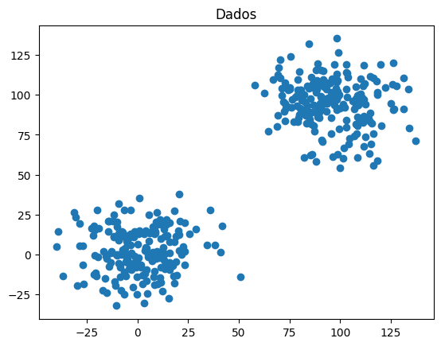

```python
from sklearn.datasets import make_biclusters
import matplotlib.pyplot as plt

data = make_biclusters(shape=(400,2),n_clusters=2,noise=15,random_state=42)[0]
lista_de_coordenadas = data.tolist()

plt.scatter(data[:,0],data[:,1])
plt.title('Dados')
plt.show()
```

```python
def get_distance(coordenadas:list) -> list:
    '''
    Função que calcula a distância euclidiana entre dois pontos
    '''
    distancias = list()
    for x1, y1 in coordenadas:
        dist = list()
        for x2, y2 in coordenadas:
            dist.append(((x1 - x2)**2 + (y1 - y2)**2)**0.5)
        distancias.append(dist)
    return distancias
```

```python
distancias = get_distance(lista_de_coordenadas)
distancias
```

```
[[0.0,
  23.654207969320773,
  122.53519406360145,
  53.57955051672816,
  107.29264513624375,
  140.53509475088248,
  41.17910132410015,
  132.83249171983843,
  45.58325957895989,
  136.94200457042774,
  119.83492987652991,
  4.058554351050769,
  112.78110137443132,
  122.74493642861952,
  122.46149592762177,
  115.97534174189491,
  52.514886026826495,
  40.800174039903474,
  20.25540441919213,
  35.79334859172535,
  125.7276700540405,
  126.45131311715224,
  35.27270601322854,
  56.43049520581767,
  105.81455891329924,
  34.14748046499764,
  122.03583361998618,
  50.85174335112553,
  51.49664088114192,
  99.42476660839708,
  47.43137946226886,
  118.80197941994292,
  29.656822876730256,
  118.40045254952369,
  47.162557391118035,
  93.05494752893648,
  96.84540091275498,
  27.84531662222287,
  114.15837275016588,
  121.62821746654416,
```

[output cut: 159945 more lines]

```
  125.05837117820754,
  14.827166498200944,
  128.20892524699724,
  36.53195194141056,
  129.66987480363886,
  133.4888830127119,
  12.891454233731928,
  142.39966270578577,
  30.07792541499436,
  9.880809155942105,
  37.738423847382826,
  1.627438115424103,
  131.93992712794332,
  124.63272106078067,
  0.0]]
```

### Questão 6

Altere o salário de joão para 8500.

```python
empregados = {
     'emp1': {'nome': 'João', 'salario': 7500},
     'emp2': {'nome': 'Patrícia', 'salario': 8000},
     'emp3': {'nome': 'Juliana', 'salario': 6500}
}
```

```python
empregados['emp1']['salario'] = 8500
```

```python
empregados
```

```
{'emp1': {'nome': 'João', 'salario': 8500},
 'emp2': {'nome': 'Patrícia', 'salario': 8000},
 'emp3': {'nome': 'Juliana', 'salario': 6500}}
```

### Questão 7

Considere a lista abaixo para resolver as próximas questões.

```python
lista_original = [15,16,17,58,95,68,35,12,12,12,44,87,95,66,78,10,12,73,155,788,157,15,25,77,185,167,142,135,172,111,121,100,101,135,196,117,156,125,189,147,155,178,142,143,156,189,178,112,113,154,144]
```

### Questão 8

Crie uma função que receba uma lista e retorna o seu desvio padrão (populacional).

```python
def get_std(lista: list) -> float:
    '''
    Função que calcula o desvio padrão populacional
    '''
    n = len(lista)
    media = sum(lista) / n

    sigma = 0
    for Xi in lista:
        sigma += (Xi - media)**2

    std = (sigma/n)**0.5

    return std
```

```python
std = get_std(lista_original)
std
```

```
111.20742384751325
```

### Questão 9

SDR (Standard Deviation Reduction) é o cálculo de redução do desvio padrão depois da quebra de um dataset utilizando uma regra. Ele consiste na seguinte fórmula.

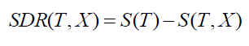

Onde :

- SDR(T,X) é redução do desvio padrão original T dado a regra X
- S(T) é o desvio padrão original
- S(T,X) é o desvio padrão ponderado utilizando a regra X.

(use desvio populacional)

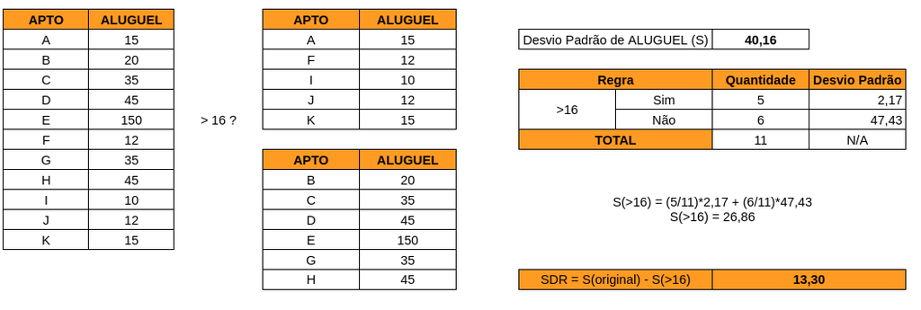

Utilizando a imagem acima como exemplo. Em um dataset de vários aluguéis utilizamos uma regra de separação quanto ao valor ser maior do que 16. Assim temos dois subsets. O primeiro tem 5 valores e um desvio padrão de 2,17, já o segundo tem 6 valores e um desvio padrão de 47,43. O desvio padrão ponderado de ambos é 26,86. A diferença entre o desvio padrão original (40,16) e dado a regra (26,86) é 13,30.

Crie um código que calcule o SDR da lista_original para cada um dos possíveis valores de regra entre 0 e 200. Guarde todos os valores de SDR em uma lista e a passe para a função plot_sdr já definida aqui.

```python
import matplotlib.pyplot as plt

def plot_sdr(lista_de_sdr):
    f,ax = plt.subplots(1,1,figsize=(16,6))
    plt.gca().spines['top'].set_visible(False)
    plt.gca().spines['right'].set_visible(False)


    ax.set_title('Comportamento de SDR',fontsize=25)
    ax.set_ylabel('SDR',fontsize=15)
    ax.plot(lista_de_sdr)

    plt.show()
```

```python
lista_stds = []
subset1 = []
subset2 = []
excluded = []
for regra in range(0, 201):
    for i in lista_original:
        if i > regra:
            subset1.append(i)
        else:
            subset2.append(i)

    if len(subset1) == 0 or len(subset2) == 0:
        subset1 = []
        subset2 = []
        excluded.append(regra)
        continue

    std_subset1 = get_std(subset1)
    std_subset2 = get_std(subset2)

    STX = (std_subset1*len(subset1) + std_subset2*len(subset2))/len(lista_original)
    subset1 = []
    subset2 = []
    lista_stds.append(std - STX)
```

```python
# Valores de regras não aplicáveis
print(excluded)
```

```
[0, 1, 2, 3, 4, 5, 6, 7, 8, 9]
```

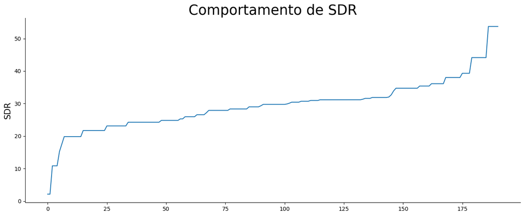

```python
plot_sdr(lista_stds)
```